# Imarticus Project : Employee Atrrition Prediction

### Group : Atul Bhaisare & Manish Dahivadkar (DSP-23)

### Use Case :

Uncover the factors that cause employees to leave the organization and explore important questions such as ‘compare average monthly income by education and attrition’ or ‘is distance from home a case for attrition’?

Build classification models to predict which employee is likely to churn and help the business to devise policies and attract back the right talent.

## Step-1 : Reading file and getting familiar with data

## 1.1 Imports

```python
import pandas as pd
import numpy as np
import sklearn
import matplotlib.pyplot as plt
import seaborn as sns
from mlxtend.plotting import plot_confusion_matrix
```

## 1.2 Reading file

```python
emp_data = pd.read_csv(r"F:\Manish_Data Science\Imarticus Project\R project\R Project - Attrition\Attrition.csv")
```

## 1.3 checking data shape (row and column count) & observe few of records

```python
emp_data.shape
```

```
(1470, 35)
```

```python
emp_data.head()
```

|  | Age | Attrition | BusinessTravel | DailyRate | Department | DistanceFromHome | Education | EducationField | EmployeeCount | EmployeeNumber | ... | RelationshipSatisfaction | StandardHours | StockOptionLevel | TotalWorkingYears | TrainingTimesLastYear | WorkLifeBalance | YearsAtCompany | YearsInCurrentRole | YearsSinceLastPromotion | YearsWithCurrManager |
| --- | --- | --- | --- | --- | --- | --- | --- | --- | --- | --- | --- | --- | --- | --- | --- | --- | --- | --- | --- | --- | --- |
| 0 | 41 | Yes | Travel_Rarely | 1102 | Sales | 1 | 2 | Life Sciences | 1 | 1 | ... | 1 | 80 | 0 | 8 | 0 | 1 | 6 | 4 | 0 | 5 |
| 1 | 49 | No | Travel_Frequently | 279 | Research & Development | 8 | 1 | Life Sciences | 1 | 2 | ... | 4 | 80 | 1 | 10 | 3 | 3 | 10 | 7 | 1 | 7 |
| 2 | 37 | Yes | Travel_Rarely | 1373 | Research & Development | 2 | 2 | Other | 1 | 4 | ... | 2 | 80 | 0 | 7 | 3 | 3 | 0 | 0 | 0 | 0 |
| 3 | 33 | No | Travel_Frequently | 1392 | Research & Development | 3 | 4 | Life Sciences | 1 | 5 | ... | 3 | 80 | 0 | 8 | 3 | 3 | 8 | 7 | 3 | 0 |
| 4 | 27 | No | Travel_Rarely | 591 | Research & Development | 2 | 1 | Medical | 1 | 7 | ... | 4 | 80 | 1 | 6 | 3 | 3 | 2 | 2 | 2 | 2 |

5 rows × 35 columns

```python
emp_data.columns
```

```
Index(['Age', 'Attrition', 'BusinessTravel', 'DailyRate', 'Department',
       'DistanceFromHome', 'Education', 'EducationField', 'EmployeeCount',
       'EmployeeNumber', 'EnvironmentSatisfaction', 'Gender', 'HourlyRate',
       'JobInvolvement', 'JobLevel', 'JobRole', 'JobSatisfaction',
       'MaritalStatus', 'MonthlyIncome', 'MonthlyRate', 'NumCompaniesWorked',
       'Over18', 'OverTime', 'PercentSalaryHike', 'PerformanceRating',
       'RelationshipSatisfaction', 'StandardHours', 'StockOptionLevel',
       'TotalWorkingYears', 'TrainingTimesLastYear', 'WorkLifeBalance',
       'YearsAtCompany', 'YearsInCurrentRole', 'YearsSinceLastPromotion',
       'YearsWithCurrManager'],
      dtype='object')
```

## 1.4 Check for Null or missing values

```python
emp_data.isnull().sum()  #...No null/missing values in dataset
```

```
Age                         0
Attrition                   0
BusinessTravel              0
DailyRate                   0
Department                  0
DistanceFromHome            0
Education                   0
EducationField              0
EmployeeCount               0
EmployeeNumber              0
EnvironmentSatisfaction     0
Gender                      0
HourlyRate                  0
JobInvolvement              0
JobLevel                    0
JobRole                     0
JobSatisfaction             0
MaritalStatus               0
MonthlyIncome               0
MonthlyRate                 0
NumCompaniesWorked          0
Over18                      0
OverTime                    0
PercentSalaryHike           0
PerformanceRating           0
RelationshipSatisfaction    0
StandardHours               0
StockOptionLevel            0
TotalWorkingYears           0
TrainingTimesLastYear       0
WorkLifeBalance             0
YearsAtCompany              0
YearsInCurrentRole          0
YearsSinceLastPromotion     0
YearsWithCurrManager        0
dtype: int64
```

# 👀Step -2 : Exploratory Data Analysis (EDA) 👀

## 2.1 Check for distribution of target variable (Attrition column)

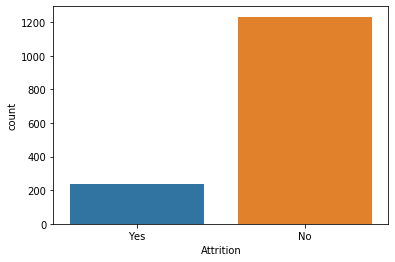

```python
sns.countplot(emp_data['Attrition']) #..we have use here countplot function from seaborn library
```

👀 From above countplot now we know that there is class imbalnce for churnout and non-churnout employees

## 2.2 check for columns conatining single unique category

```python
emp_data.nunique().sort_values(ascending=True).reset_index(name= "Column unique count")
```

|  | index | Column unique count |
| --- | --- | --- |
| 0 | Over18 | 1 |
| 1 | StandardHours | 1 |
| 2 | EmployeeCount | 1 |
| 3 | Gender | 2 |
| 4 | Attrition | 2 |
| 5 | PerformanceRating | 2 |
| 6 | OverTime | 2 |
| 7 | MaritalStatus | 3 |
| 8 | Department | 3 |
| 9 | BusinessTravel | 3 |
| 10 | StockOptionLevel | 4 |
| 11 | EnvironmentSatisfaction | 4 |
| 12 | JobInvolvement | 4 |
| 13 | JobSatisfaction | 4 |
| 14 | RelationshipSatisfaction | 4 |
| 15 | WorkLifeBalance | 4 |
| 16 | Education | 5 |
| 17 | JobLevel | 5 |
| 18 | EducationField | 6 |
| 19 | TrainingTimesLastYear | 7 |
| 20 | JobRole | 9 |
| 21 | NumCompaniesWorked | 10 |
| 22 | PercentSalaryHike | 15 |
| 23 | YearsSinceLastPromotion | 16 |
| 24 | YearsWithCurrManager | 18 |
| 25 | YearsInCurrentRole | 19 |
| 26 | DistanceFromHome | 29 |
| 27 | YearsAtCompany | 37 |
| 28 | TotalWorkingYears | 40 |
| 29 | Age | 43 |
| 30 | HourlyRate | 71 |
| 31 | DailyRate | 886 |
| 32 | MonthlyIncome | 1349 |
| 33 | MonthlyRate | 1427 |
| 34 | EmployeeNumber | 1470 |

##### 👀 From above output now we know that columns "EmployeeCount ", "Over18 ","StandardHours" has single unique value. And hence do not has any impact on decision making.

## 2.3 Check for how Age and Attrition related

```python
emp_data.groupby(["Attrition"]).Age.mean()
```

```
Attrition
No     37.561233
Yes    33.607595
Name: Age, dtype: float64
```

#### ->Lets convert our target variable into numeric categories so we can plot distribution plot

```python
emp_data.Attrition.replace({"Yes":1,"No":0}, inplace = True)
```

```python
attri_yes = emp_data.loc[emp_data["Attrition"]==1]
attri_no = emp_data.loc[emp_data["Attrition"]==0]
```

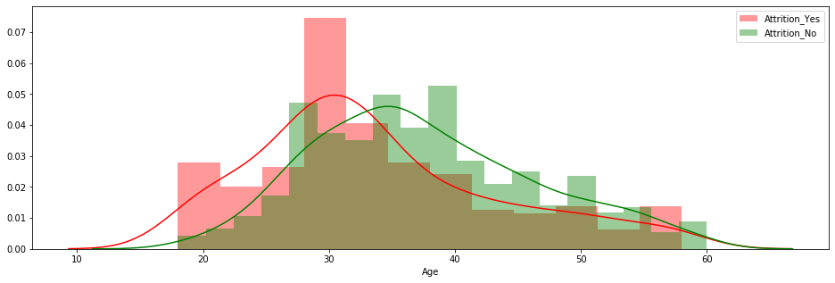

```python
plt.figure(figsize=(16,5))
sns.distplot(attri_yes["Age"],color="red",label= "Attrition_Yes")
sns.distplot(attri_no["Age"], color="green", label= "Attrition_No")
plt.legend()
```

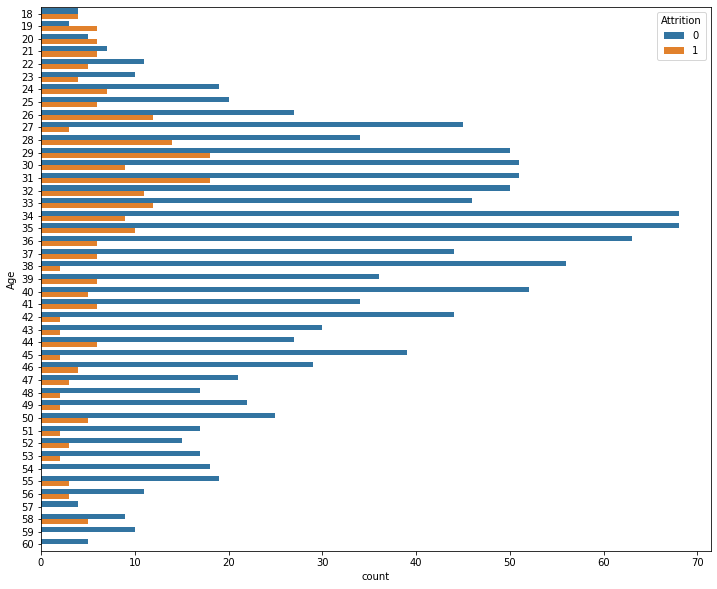

```python
plt.figure(figsize=(12,10))
sns.countplot(y="Age", hue="Attrition", data=emp_data)
```

#### 🤷‍INSIGHT : From above visualization we can say employees having age below 35 years has more attrtition rate

## 2.4 How Attrition is related with Business Travel

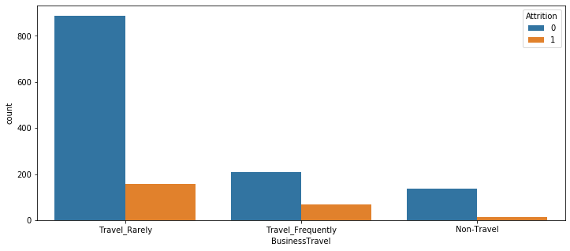

```python
plt.figure(figsize=(12,5))
sns.countplot(x="BusinessTravel", hue="Attrition", data=emp_data)
```

## 2.5 Relation between Dailyrate and Attrition

##### while counting unique values we have seen there are 886 uniques in Dailyrate column and hence we will not visualization , instaed we will use min , max and average value to decide on pattern among attrtion

```python
emp_data.groupby("Attrition").DailyRate.agg(["count","min","max","mean"])
```

| Attrition | count | min | max | mean |
| --- | --- | --- | --- | --- |
| 0 | 1233 | 102 | 1499 | 812.504461 |
| 1 | 237 | 103 | 1496 | 750.362869 |

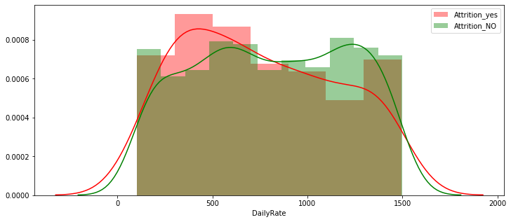

```python
plt.figure(figsize=(12,5))
sns.distplot(attri_yes["DailyRate"],color="red",label= "Attrition_yes")
sns.distplot(attri_no["DailyRate"], color="green", label= "Attrition_NO")
plt.legend()
```

#### 🤷‍INSIGHT : There is same pattern of Daily Rate for both churnout and non-churnout employees. Hence this column has less impact on decision making

# 2.6 Department wise Attrition

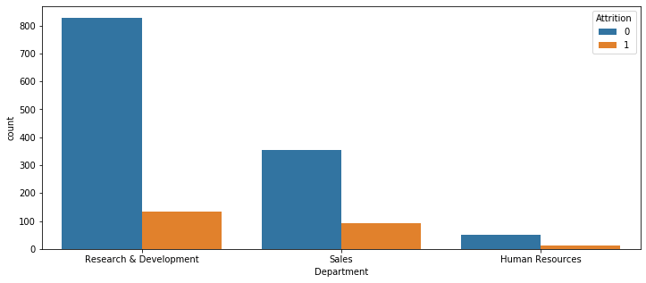

```python
plt.figure(figsize=(12,5))
sns.countplot(x="Department", hue="Attrition", data=emp_data, order = emp_data["Department"].value_counts().index)
```

#### 🤷‍INSIGHT : There is same pattern of churnout and non-churnout employees in difefren deapartemnts

## 2.7 Effect of Distance From Home on Attrition

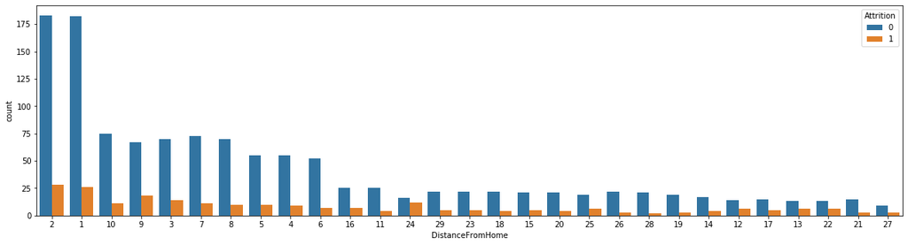

```python
plt.figure(figsize=(20,5))
sns.countplot(x="DistanceFromHome", hue="Attrition", data=emp_data, order = emp_data["DistanceFromHome"].value_counts().index)
```

```python
emp_data.groupby("Attrition").DistanceFromHome.agg(["count","min","max","mean"])
```

| Attrition | count | min | max | mean |
| --- | --- | --- | --- | --- |
| 0 | 1233 | 1 | 29 | 8.915653 |
| 1 | 237 | 1 | 29 | 10.632911 |

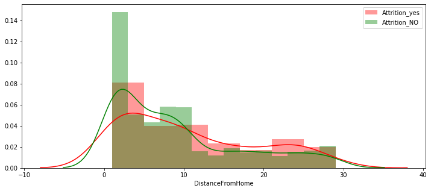

```python
plt.figure(figsize=(12,5))
sns.distplot(attri_yes["DistanceFromHome"],color="red",label= "Attrition_yes")
sns.distplot(attri_no["DistanceFromHome"], color="green", label= "Attrition_NO")
plt.legend()
```

#### 🤷‍INSIGHT : Distance from Home is not crucial cause for employee to leave the job

## 2.8 Education wise who is leaving more

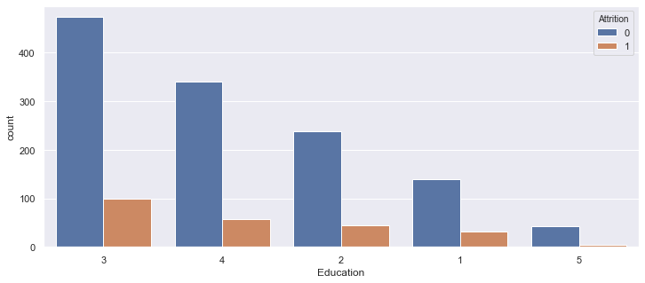

```python
sns.set(style="darkgrid")
plt.figure(figsize=(12,5))
sns.countplot(x="Education", hue="Attrition", data=emp_data, order = emp_data["Education"].value_counts().index)
```

##### Education 1 'Below College' 2 'College' 3 'Bachelor' 4 'Master' 5 'Doctor'

### 🤷‍INSIGHT : Almost same pattern in all eductaion levels . count wise attrition rate is high in Bachelors and Masters holders

## 2.9 Educational Field and Attrition rate

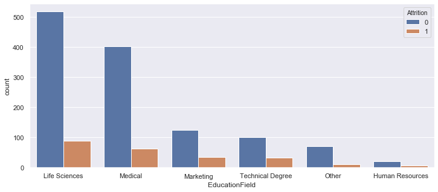

```python
sns.set()
plt.figure(figsize=(12,5))
sns.countplot(x="EducationField", hue="Attrition", data=emp_data, order = emp_data["EducationField"].value_counts().index)
```

##### 🤷‍ INSIGHT : No specific eduction wise pattern of attrition rate .🤷‍

## 2.10 Environment Satisfaction and Attrition rate

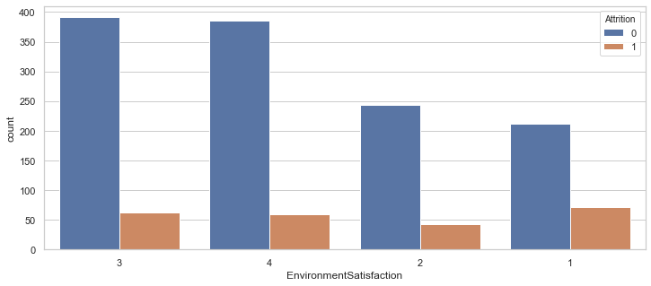

```python
sns.set(style= "whitegrid")
plt.figure(figsize=(12,5))
sns.countplot(x="EnvironmentSatisfaction", hue="Attrition", data=emp_data,order = emp_data["EnvironmentSatisfaction"].value_counts().index)
```

#### Environment Satisfaction : 1 'Low' 2 'Medium' 3 'High' 4 'Very High'

#### 🤷‍ INSIGHT : Comparatively high attrtition rate in employees having low environment satisfaction 🤷‍

## 2.11 Gender and Attrition

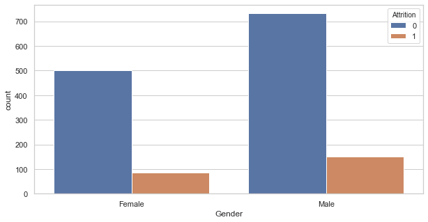

```python
plt.figure(figsize=(10,5))
sns.countplot(x="Gender", hue="Attrition", data=emp_data)
```

### 🤷‍ INSIGHT : Same pattern of Attrition in Males and Females.🤷‍

## 2.12 HourlyRate and Attrition

```python
emp_data.groupby("Attrition").HourlyRate.agg(["count","min","max","mean"])
```

| Attrition | count | min | max | mean |
| --- | --- | --- | --- | --- |
| 0 | 1233 | 30 | 100 | 65.952149 |
| 1 | 237 | 31 | 100 | 65.573840 |

#### 🤷‍ INSIGHT : Hourly Rate has no significant impact on Attrition 🤷‍

## 2.13 Job Involvement and Attrition

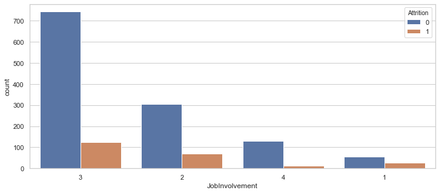

```python
sns.set(style="whitegrid")
plt.figure(figsize=(12,5))
sns.countplot(x="JobInvolvement", hue="Attrition", data=emp_data, order = emp_data["JobInvolvement"].value_counts().index)
```

#### JobInvolvement : 1 'Low' 2 'Medium' 3 'High' 4 'Very High'

#### 🤷‍ INSIGHT : People with very high job involvement has lowest Attrition 🤷‍

## 2.14 JobLevel and Attrition

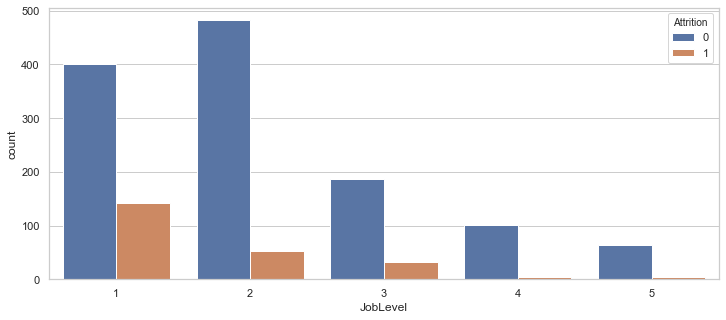

```python
sns.set(style="whitegrid")
plt.figure(figsize=(12,5))
sns.countplot(x="JobLevel", hue="Attrition", data=emp_data, order = emp_data["JobLevel"].value_counts().index)
```

#### 🤷‍ INSIGHT : People with job-level 4 & 5 has lowest Attrition 🤷‍

## 2.15 JobRole and Attrition

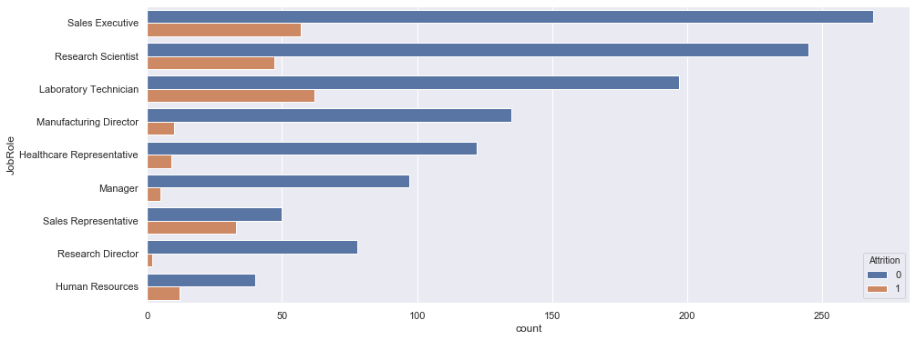

```python
sns.set(style="darkgrid")
plt.figure(figsize=(15,6))
sns.countplot(y="JobRole", hue="Attrition", data=emp_data, order = emp_data["JobRole"].value_counts().index)
```

#### 🤷‍ INSIGHT : There is lowest attrition in upper management roles like directors and managers 🤷‍

## 2.16 JobSatisfaction and Attrition

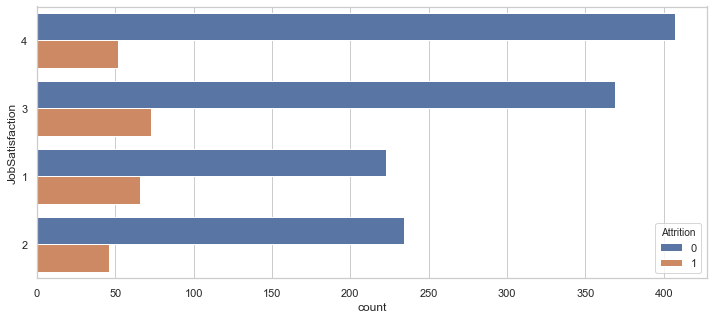

```python
sns.set(style="whitegrid")
plt.figure(figsize=(12,5))
sns.countplot(y="JobSatisfaction", hue="Attrition", data=emp_data, order = emp_data["JobSatisfaction"].value_counts().index)
```

#### JobSatisfaction : 1 'Low' 2 'Medium' 3 'High' 4 'Very High'

#### 🤷‍ INSIGHT : Realtively low attrition in employees having job saisfaction high and very high 🤷‍

## 2.17 Marital Status and Attrition

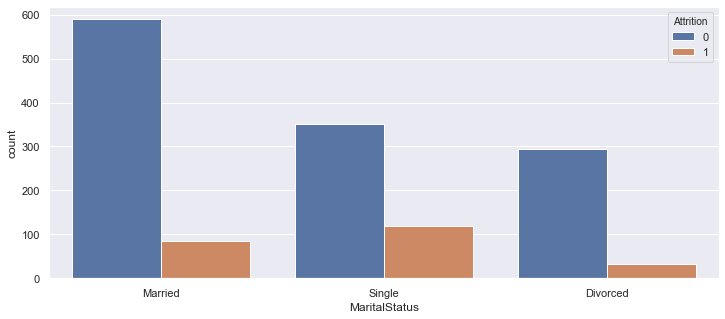

```python
sns.set(style="darkgrid")
plt.figure(figsize=(12,5))
sns.countplot(x="MaritalStatus", hue="Attrition", data=emp_data, order = emp_data["MaritalStatus"].value_counts().index)
```

#### 🤷‍ INSIGHT : Realtively High attrition in single employees 🤷‍

## 2.18 Number of Companies Worked and Attrition rate

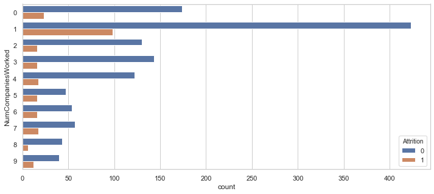

```python
sns.set(style="whitegrid")
plt.figure(figsize=(12,5))
sns.countplot(y="NumCompaniesWorked", hue="Attrition", data=emp_data)
```

## 2.18 Overtime and Attrition rate

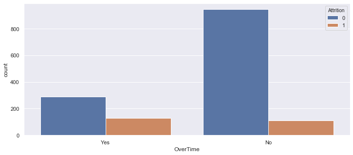

```python
sns.set(style="darkgrid")
plt.figure(figsize=(12,5))
sns.countplot(x="OverTime", hue="Attrition", data=emp_data)
```

#### 🤷‍ INSIGHT : People who need to do Overtime has highest attrition rate 🤷‍

## 2.19 Percent Salary Hike and Attrition rate

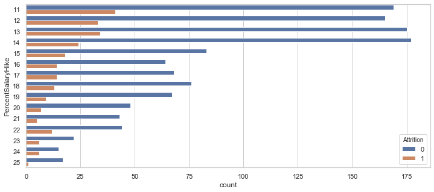

```python
sns.set(style="whitegrid")
plt.figure(figsize=(12,5))
sns.countplot(y="PercentSalaryHike", hue="Attrition", data=emp_data)
```

#### 🤷‍ INSIGHT : People who recieved below 19 % salary hike has highest attrition rate 🤷‍

## 2.20 PerformanceRating and Attrition rate

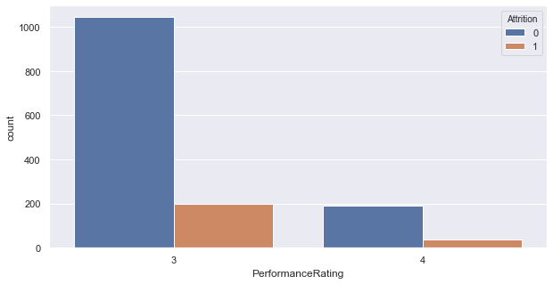

```python
sns.set(style="darkgrid")
plt.figure(figsize=(10,5))
sns.countplot(x="PerformanceRating", hue="Attrition", data=emp_data)
```

#### 🤷‍ INSIGHT : No significant insights from available data 🤷‍

## 2.21 Relationship Satisfaction and Attrition rate

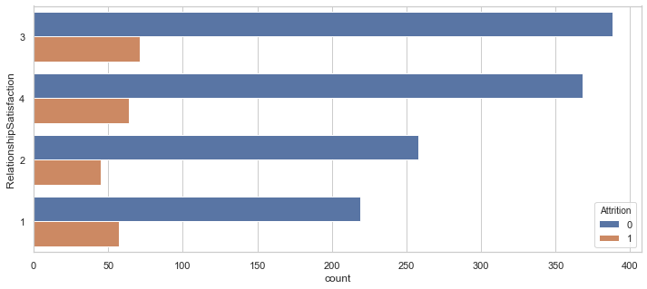

```python
sns.set(style="whitegrid")
plt.figure(figsize=(12,5))
sns.countplot(y="RelationshipSatisfaction", hue="Attrition", data=emp_data, order = emp_data["RelationshipSatisfaction"].value_counts().index)
```

#### Relationship Satisfaction : 1 'Low' 2 'Medium' 3 'High' 4 'Very High'

#### 🤷‍ INSIGHT : Relatively high attrtion rate in employees having low relationship satisfaction 🤷‍

## 2.22 Stock Option Level and Attrition rate

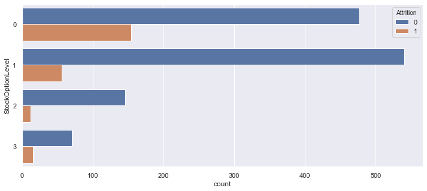

```python
sns.set(style="darkgrid")
plt.figure(figsize=(12,5))
sns.countplot(y="StockOptionLevel", hue="Attrition", data=emp_data)
```

#### 🤷‍ INSIGHT : Relatively high attrtion rate in employees who has stock option level 0 🤷‍

## 2.23 Total Working Years and Attrition rate

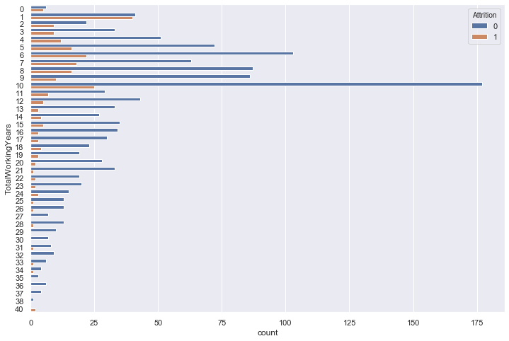

```python
sns.set(style="darkgrid")
plt.figure(figsize=(12,8))
sns.countplot(y="TotalWorkingYears", hue="Attrition", data=emp_data)
```

#### 🤷‍ INSIGHT : Relatively high attrtion rate in people who's working experience is below 13 years 🤷‍

## 2.24 Training Times Last Year and Attrition rate

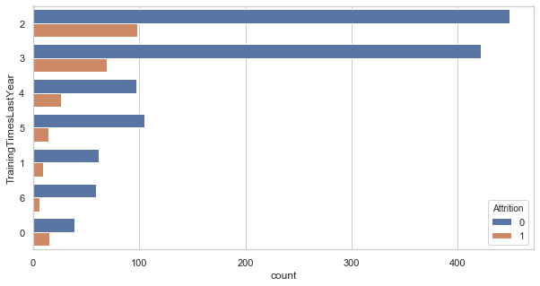

```python
sns.set(style="whitegrid")
plt.figure(figsize=(10,5))
sns.countplot(y="TrainingTimesLastYear", hue="Attrition", data=emp_data,order = emp_data["TrainingTimesLastYear"].value_counts().index)
```

#### 🤷‍ INSIGHT : No significant information regarding attrition rate pattern 🤷‍

## 2.25 WorkLife Balance and Attrition rate

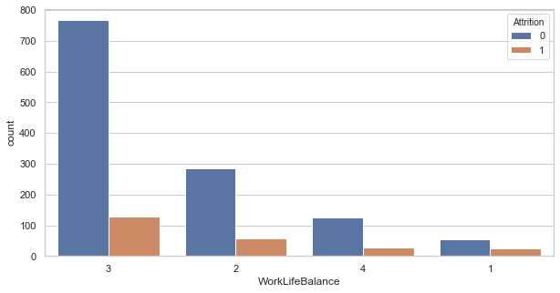

```python
sns.set(style="whitegrid")
plt.figure(figsize=(10,5))
sns.countplot(x="WorkLifeBalance", hue="Attrition", data=emp_data,order = emp_data["WorkLifeBalance"].value_counts().index)
```

#### WorkLifeBalance : 1 'Bad' 2 'Good' 3 'Better' 4 'Best'

#### 🤷‍ INSIGHT : Reatively high proportion of attrition rate in Work Life Balance category 1 & 2 🤷‍

## 2.26 Years At Company and Attrition rate

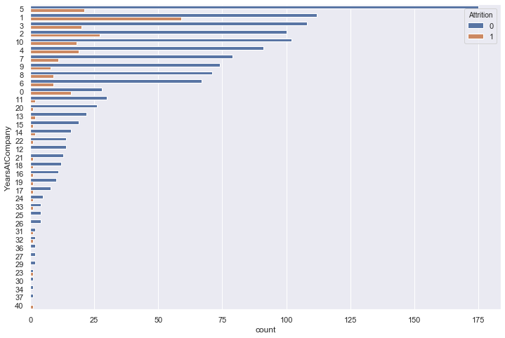

```python
sns.set(style="darkgrid")
plt.figure(figsize=(12,8))
sns.countplot(y="YearsAtCompany", hue="Attrition", data=emp_data, order = emp_data["YearsAtCompany"].value_counts().index)
```

#### 🤷‍ INSIGHT : Reatively high proportion of attrition rate n employees who has spend below than <11 years at company 🤷‍

## 2.27 Years In Current Role and Attrition rate

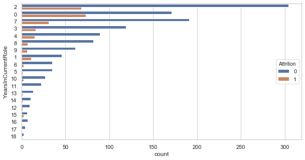

```python
sns.set(style="whitegrid")
plt.figure(figsize=(10,5))
sns.countplot(y="YearsInCurrentRole", hue="Attrition", data=emp_data, order = emp_data["YearsInCurrentRole"].value_counts().index)
```

#### 🤷‍ INSIGHT : High attrition rate in employees who has spend below 5 years in current role 🤷‍

## 2.28 Years Since Last Promotion and Attrition rate

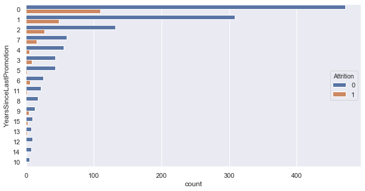

```python
sns.set(style="darkgrid")
plt.figure(figsize=(10,5))
sns.countplot(y="YearsSinceLastPromotion", hue="Attrition", data=emp_data, order = emp_data["YearsSinceLastPromotion"].value_counts().index)
```

#### 🤷‍ INSIGHT : 0 years since last promotion indicates either no promotion or recently promoted (less than 1 year), this category has highest attrition rate 🤷‍

## 2.29 Years With Current Manager and Attrition rate

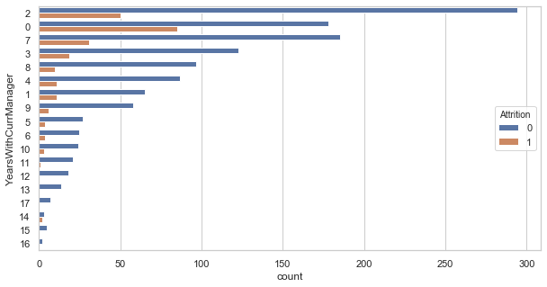

```python
sns.set(style="whitegrid")
plt.figure(figsize=(10,5))
sns.countplot(y="YearsWithCurrManager", hue="Attrition", data=emp_data,order = emp_data["YearsWithCurrManager"].value_counts().index)
```

#### 🤷‍ INSIGHT : Employees who has spend less than 1 year with current manager has highest attrition rate 🤷‍

# Step-3 : Summary of Important Insights

### 3.1 Provided data has class imblance for target variable.

### 3.2 There are three columns in dataset namely EmployeeCount','Over18' ,'StandardHours' which contains unique single entry and hene has no impact on decision making.

### 3.3 Features related to High attrition rate

1) Employees below 35 years of age has more attrition rate.

2) Employees having level 1 (low) job satisfaction has high attrition rate

3) Employees with realtionship status single has high attrition rate

4) Employees who does overtime has more attrition rate

5) Employees who received below 19 % salary hike has more attrition rate

6) High attrition rate in employees having low realtionship satisfaction

7) Employees with stock option level 0 has more attrition rate

8) High attrition rate among employees having below 13 years of working experience

9) Employees who has spend less than 1 year with current manager has highest attrition rate

10) 0 years since last promotion indicates either no promotion or recently promoted (less than 1 year), this category has highest attrition rate

11) Relatively high proportion of attrition rate in emplloyees having work life balance category 1 & 2

### 3.4 Features related to Low attrition rate

1.Employees with very high job involvement has lowest attrition rate

2.People with job level 4 & 5 has lowest attrition rate

3.Job roles Manufacturing director, Research director, Healthcare Represenatative and Manager has lowest attrition rate

4.Low attrition rate in employees who have completed more tahn 10 years in current company

# Step-4 : Initial level Feature Engineering

### 4.1 Identify Feature columns having object type categories

```python
categorical_emp_data=emp_data.select_dtypes(include= ["object"])
categorical_emp_data.columns
```

```
Index(['BusinessTravel', 'Department', 'EducationField', 'Gender', 'JobRole',
       'MaritalStatus', 'Over18', 'OverTime'],
      dtype='object')
```

### 4.2 Replace object type categorical data by numeric categories

```python
import sklearn
from sklearn.preprocessing import LabelEncoder
```

```python
le = LabelEncoder() # cretaed instance for label encoder
```

```python
emp_data.BusinessTravel=le.fit_transform(emp_data.BusinessTravel)
emp_data.Department=le.fit_transform(emp_data.Department)
emp_data.EducationField=le.fit_transform(emp_data.EducationField)
emp_data.Gender=le.fit_transform(emp_data.Gender)
emp_data.JobRole=le.fit_transform(emp_data.JobRole)
emp_data.MaritalStatus=le.fit_transform(emp_data.MaritalStatus)
emp_data.Over18=le.fit_transform(emp_data.Over18)
emp_data.OverTime=le.fit_transform(emp_data.OverTime)
```

To get treated as catgories and not numeric , we need to factorise converted numeric data of above columns

# 5 Feature Selection

### 5.1 In EDA step we have identified 3 columns where single unique values are present and hence we can remove these columns due no impact on decision making

```python
emp_data= emp_data.drop(columns=["EmployeeCount", "Over18","StandardHours"])
```

### 5.2 Identification of Highly correlated Features

```python
emp_data_corr=emp_data.corr()
emp_data_corr
```

|  | Age | Attrition | BusinessTravel | DailyRate | Department | DistanceFromHome | Education | EducationField | EmployeeNumber | EnvironmentSatisfaction | ... | PerformanceRating | RelationshipSatisfaction | StockOptionLevel | TotalWorkingYears | TrainingTimesLastYear | WorkLifeBalance | YearsAtCompany | YearsInCurrentRole | YearsSinceLastPromotion | YearsWithCurrManager |
| --- | --- | --- | --- | --- | --- | --- | --- | --- | --- | --- | --- | --- | --- | --- | --- | --- | --- | --- | --- | --- | --- |
| Age | 1.000000 | -0.159205 | 0.024751 | 0.010661 | -0.031882 | -0.001686 | 0.208034 | -0.040873 | -0.010145 | 0.010146 | ... | 0.001904 | 0.053535 | 0.037510 | 0.680381 | -0.019621 | -0.021490 | 0.311309 | 0.212901 | 0.216513 | 0.202089 |
| Attrition | -0.159205 | 1.000000 | 0.000074 | -0.056652 | 0.063991 | 0.077924 | -0.031373 | 0.026846 | -0.010577 | -0.103369 | ... | 0.002889 | -0.045872 | -0.137145 | -0.171063 | -0.059478 | -0.063939 | -0.134392 | -0.160545 | -0.033019 | -0.156199 |
| BusinessTravel | 0.024751 | 0.000074 | 1.000000 | -0.004086 | -0.009044 | -0.024469 | 0.000757 | 0.023724 | -0.015578 | 0.004174 | ... | -0.026341 | -0.035986 | -0.016727 | 0.034226 | 0.015240 | -0.011256 | -0.014575 | -0.011497 | -0.032591 | -0.022636 |
| DailyRate | 0.010661 | -0.056652 | -0.004086 | 1.000000 | 0.007109 | -0.004985 | -0.016806 | 0.037709 | -0.050990 | 0.018355 | ... | 0.000473 | 0.007846 | 0.042143 | 0.014515 | 0.002453 | -0.037848 | -0.034055 | 0.009932 | -0.033229 | -0.026363 |
| Department | -0.031882 | 0.063991 | -0.009044 | 0.007109 | 1.000000 | 0.017225 | 0.007996 | 0.013720 | -0.010895 | -0.019395 | ... | -0.024604 | -0.022414 | -0.012193 | -0.015762 | 0.036875 | 0.026383 | 0.022920 | 0.056315 | 0.040061 | 0.034282 |
| DistanceFromHome | -0.001686 | 0.077924 | -0.024469 | -0.004985 | 0.017225 | 1.000000 | 0.021042 | 0.002013 | 0.032916 | -0.016075 | ... | 0.027110 | 0.006557 | 0.044872 | 0.004628 | -0.036942 | -0.026556 | 0.009508 | 0.018845 | 0.010029 | 0.014406 |
| Education | 0.208034 | -0.031373 | 0.000757 | -0.016806 | 0.007996 | 0.021042 | 1.000000 | -0.039592 | 0.042070 | -0.027128 | ... | -0.024539 | -0.009118 | 0.018422 | 0.148280 | -0.025100 | 0.009819 | 0.069114 | 0.060236 | 0.054254 | 0.069065 |
| EducationField | -0.040873 | 0.026846 | 0.023724 | 0.037709 | 0.013720 | 0.002013 | -0.039592 | 1.000000 | -0.002516 | 0.043163 | ... | -0.005614 | -0.004378 | -0.016185 | -0.027848 | 0.049195 | 0.041191 | -0.018692 | -0.010506 | 0.002326 | -0.004130 |
| EmployeeNumber | -0.010145 | -0.010577 | -0.015578 | -0.050990 | -0.010895 | 0.032916 | 0.042070 | -0.002516 | 1.000000 | 0.017621 | ... | -0.020359 | -0.069861 | 0.062227 | -0.014365 | 0.023603 | 0.010309 | -0.011240 | -0.008416 | -0.009019 | -0.009197 |
| EnvironmentSatisfaction | 0.010146 | -0.103369 | 0.004174 | 0.018355 | -0.019395 | -0.016075 | -0.027128 | 0.043163 | 0.017621 | 1.000000 | ... | -0.029548 | 0.007665 | 0.003432 | -0.002693 | -0.019359 | 0.027627 | 0.001458 | 0.018007 | 0.016194 | -0.004999 |
| Gender | -0.036311 | 0.029453 | -0.032981 | -0.011716 | -0.041583 | -0.001851 | -0.016547 | -0.002504 | 0.022556 | 0.000508 | ... | -0.013859 | 0.022868 | 0.012716 | -0.046881 | -0.038787 | -0.002753 | -0.029747 | -0.041483 | -0.026985 | -0.030599 |
| HourlyRate | 0.024287 | -0.006846 | 0.026528 | 0.023381 | -0.004144 | 0.031131 | 0.016775 | -0.021941 | 0.035179 | -0.049857 | ... | -0.002172 | 0.001330 | 0.050263 | -0.002334 | -0.008548 | -0.004607 | -0.019582 | -0.024106 | -0.026716 | -0.020123 |
| JobInvolvement | 0.029820 | -0.130016 | 0.039062 | 0.046135 | -0.024586 | 0.008783 | 0.042438 | -0.002655 | -0.006888 | -0.008278 | ... | -0.029071 | 0.034297 | 0.021523 | -0.005533 | -0.015338 | -0.014617 | -0.021355 | 0.008717 | -0.024184 | 0.025976 |
| JobLevel | 0.509604 | -0.169105 | 0.019311 | 0.002966 | 0.101963 | 0.005303 | 0.101589 | -0.044933 | -0.018519 | 0.001212 | ... | -0.021222 | 0.021642 | 0.013984 | 0.782208 | -0.018191 | 0.037818 | 0.534739 | 0.389447 | 0.353885 | 0.375281 |
| JobRole | -0.122427 | 0.067151 | 0.002724 | -0.009472 | 0.662431 | -0.001015 | 0.004236 | 0.015599 | -0.010336 | -0.017321 | ... | -0.024233 | -0.020218 | -0.019171 | -0.145439 | 0.001342 | 0.027764 | -0.083657 | -0.028354 | -0.046384 | -0.041150 |
| JobSatisfaction | -0.004892 | -0.103481 | -0.033962 | 0.030571 | 0.021001 | -0.003669 | -0.011296 | -0.034401 | -0.046247 | -0.006784 | ... | 0.002297 | -0.012454 | 0.010690 | -0.020185 | -0.005779 | -0.019459 | -0.003803 | -0.002305 | -0.018214 | -0.027656 |
| MaritalStatus | -0.095029 | 0.162070 | 0.024001 | -0.069586 | 0.056073 | -0.014437 | 0.004053 | 0.014420 | -0.008155 | -0.003593 | ... | 0.005207 | 0.022549 | -0.662577 | -0.077886 | 0.010629 | 0.014708 | -0.059986 | -0.065822 | -0.030915 | -0.038570 |
| MonthlyIncome | 0.497855 | -0.159840 | 0.034319 | 0.007707 | 0.053130 | -0.017014 | 0.094961 | -0.041070 | -0.014829 | -0.006259 | ... | -0.017120 | 0.025873 | 0.005408 | 0.772893 | -0.021736 | 0.030683 | 0.514285 | 0.363818 | 0.344978 | 0.344079 |
| MonthlyRate | 0.028051 | 0.015170 | -0.014107 | -0.032182 | 0.023642 | 0.027473 | -0.026084 | -0.027182 | 0.012648 | 0.037600 | ... | -0.009811 | -0.004085 | -0.034323 | 0.026442 | 0.001467 | 0.007963 | -0.023655 | -0.012815 | 0.001567 | -0.036746 |
| NumCompaniesWorked | 0.299635 | 0.043494 | 0.020875 | 0.038153 | -0.035882 | -0.029251 | 0.126317 | -0.008663 | -0.001251 | 0.012594 | ... | -0.014095 | 0.052733 | 0.030075 | 0.237639 | -0.066054 | -0.008366 | -0.118421 | -0.090754 | -0.036814 | -0.110319 |
| OverTime | 0.028062 | 0.246118 | 0.016543 | 0.009135 | 0.007481 | 0.025514 | -0.020322 | 0.002259 | -0.024037 | 0.070132 | ... | 0.004369 | 0.048493 | -0.000449 | 0.012754 | -0.079113 | -0.027092 | -0.011687 | -0.029758 | -0.012239 | -0.041586 |
| PercentSalaryHike | 0.003634 | -0.013478 | -0.029377 | 0.022704 | -0.007840 | 0.040235 | -0.011111 | -0.011214 | -0.012944 | -0.031701 | ... | 0.773550 | -0.040490 | 0.007528 | -0.020608 | -0.005221 | -0.003280 | -0.035991 | -0.001520 | -0.022154 | -0.011985 |
| PerformanceRating | 0.001904 | 0.002889 | -0.026341 | 0.000473 | -0.024604 | 0.027110 | -0.024539 | -0.005614 | -0.020359 | -0.029548 | ... | 1.000000 | -0.031351 | 0.003506 | 0.006744 | -0.015579 | 0.002572 | 0.003435 | 0.034986 | 0.017896 | 0.022827 |
| RelationshipSatisfaction | 0.053535 | -0.045872 | -0.035986 | 0.007846 | -0.022414 | 0.006557 | -0.009118 | -0.004378 | -0.069861 | 0.007665 | ... | -0.031351 | 1.000000 | -0.045952 | 0.024054 | 0.002497 | 0.019604 | 0.019367 | -0.015123 | 0.033493 | -0.000867 |
| StockOptionLevel | 0.037510 | -0.137145 | -0.016727 | 0.042143 | -0.012193 | 0.044872 | 0.018422 | -0.016185 | 0.062227 | 0.003432 | ... | 0.003506 | -0.045952 | 1.000000 | 0.010136 | 0.011274 | 0.004129 | 0.015058 | 0.050818 | 0.014352 | 0.024698 |
| TotalWorkingYears | 0.680381 | -0.171063 | 0.034226 | 0.014515 | -0.015762 | 0.004628 | 0.148280 | -0.027848 | -0.014365 | -0.002693 | ... | 0.006744 | 0.024054 | 0.010136 | 1.000000 | -0.035662 | 0.001008 | 0.628133 | 0.460365 | 0.404858 | 0.459188 |
| TrainingTimesLastYear | -0.019621 | -0.059478 | 0.015240 | 0.002453 | 0.036875 | -0.036942 | -0.025100 | 0.049195 | 0.023603 | -0.019359 | ... | -0.015579 | 0.002497 | 0.011274 | -0.035662 | 1.000000 | 0.028072 | 0.003569 | -0.005738 | -0.002067 | -0.004096 |
| WorkLifeBalance | -0.021490 | -0.063939 | -0.011256 | -0.037848 | 0.026383 | -0.026556 | 0.009819 | 0.041191 | 0.010309 | 0.027627 | ... | 0.002572 | 0.019604 | 0.004129 | 0.001008 | 0.028072 | 1.000000 | 0.012089 | 0.049856 | 0.008941 | 0.002759 |
| YearsAtCompany | 0.311309 | -0.134392 | -0.014575 | -0.034055 | 0.022920 | 0.009508 | 0.069114 | -0.018692 | -0.011240 | 0.001458 | ... | 0.003435 | 0.019367 | 0.015058 | 0.628133 | 0.003569 | 0.012089 | 1.000000 | 0.758754 | 0.618409 | 0.769212 |
| YearsInCurrentRole | 0.212901 | -0.160545 | -0.011497 | 0.009932 | 0.056315 | 0.018845 | 0.060236 | -0.010506 | -0.008416 | 0.018007 | ... | 0.034986 | -0.015123 | 0.050818 | 0.460365 | -0.005738 | 0.049856 | 0.758754 | 1.000000 | 0.548056 | 0.714365 |
| YearsSinceLastPromotion | 0.216513 | -0.033019 | -0.032591 | -0.033229 | 0.040061 | 0.010029 | 0.054254 | 0.002326 | -0.009019 | 0.016194 | ... | 0.017896 | 0.033493 | 0.014352 | 0.404858 | -0.002067 | 0.008941 | 0.618409 | 0.548056 | 1.000000 | 0.510224 |
| YearsWithCurrManager | 0.202089 | -0.156199 | -0.022636 | -0.026363 | 0.034282 | 0.014406 | 0.069065 | -0.004130 | -0.009197 | -0.004999 | ... | 0.022827 | -0.000867 | 0.024698 | 0.459188 | -0.004096 | 0.002759 | 0.769212 | 0.714365 | 0.510224 | 1.000000 |

32 rows × 32 columns

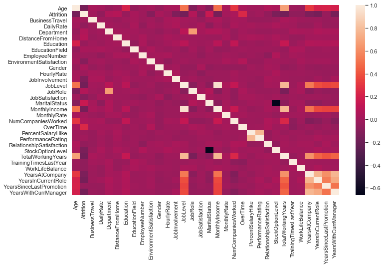

```python
plt.figure(figsize=(12,7))
sns.heatmap(emp_data_corr,xticklabels=emp_data_corr.columns,yticklabels=emp_data_corr.columns)
```

```python
upper = emp_data_corr.where(np.triu(np.ones(emp_data_corr.shape), k=1).astype(np.bool))
to_drop = [column for column in upper.columns if any(upper[column] > 0.80)]
to_drop
```

```
['MonthlyIncome']
```

```python
emp_data= emp_data.drop(columns=["MonthlyIncome"])
```

```python
emp_data.shape
```

```
(1470, 31)
```

```python
emp_data.head(5)
```

|  | Age | Attrition | BusinessTravel | DailyRate | Department | DistanceFromHome | Education | EducationField | EmployeeNumber | EnvironmentSatisfaction | ... | PerformanceRating | RelationshipSatisfaction | StockOptionLevel | TotalWorkingYears | TrainingTimesLastYear | WorkLifeBalance | YearsAtCompany | YearsInCurrentRole | YearsSinceLastPromotion | YearsWithCurrManager |
| --- | --- | --- | --- | --- | --- | --- | --- | --- | --- | --- | --- | --- | --- | --- | --- | --- | --- | --- | --- | --- | --- |
| 0 | 41 | 1 | 2 | 1102 | 2 | 1 | 2 | 1 | 1 | 2 | ... | 3 | 1 | 0 | 8 | 0 | 1 | 6 | 4 | 0 | 5 |
| 1 | 49 | 0 | 1 | 279 | 1 | 8 | 1 | 1 | 2 | 3 | ... | 4 | 4 | 1 | 10 | 3 | 3 | 10 | 7 | 1 | 7 |
| 2 | 37 | 1 | 2 | 1373 | 1 | 2 | 2 | 4 | 4 | 4 | ... | 3 | 2 | 0 | 7 | 3 | 3 | 0 | 0 | 0 | 0 |
| 3 | 33 | 0 | 1 | 1392 | 1 | 3 | 4 | 1 | 5 | 4 | ... | 3 | 3 | 0 | 8 | 3 | 3 | 8 | 7 | 3 | 0 |
| 4 | 27 | 0 | 2 | 591 | 1 | 2 | 1 | 3 | 7 | 1 | ... | 3 | 4 | 1 | 6 | 3 | 3 | 2 | 2 | 2 | 2 |

5 rows × 31 columns

# 6. X & Y Split and sampling (Train and Test)

### 6.1 Creat new dataframe (emp_data_Y) for target variable

```python
emp_data_y=emp_data.Attrition
emp_data_y.head()
```

```
0    1
1    0
2    1
3    0
4    0
Name: Attrition, dtype: int64
```

```python
emp_data_y.isnull().sum()
```

```
0
```

### 6.2 Create second dataframe (emp_data_x) for Independent variables

```python
emp_data_x=emp_data.drop(['Attrition'],axis=1)
emp_data_x.head()
```

|  | Age | BusinessTravel | DailyRate | Department | DistanceFromHome | Education | EducationField | EmployeeNumber | EnvironmentSatisfaction | Gender | ... | PerformanceRating | RelationshipSatisfaction | StockOptionLevel | TotalWorkingYears | TrainingTimesLastYear | WorkLifeBalance | YearsAtCompany | YearsInCurrentRole | YearsSinceLastPromotion | YearsWithCurrManager |
| --- | --- | --- | --- | --- | --- | --- | --- | --- | --- | --- | --- | --- | --- | --- | --- | --- | --- | --- | --- | --- | --- |
| 0 | 41 | 2 | 1102 | 2 | 1 | 2 | 1 | 1 | 2 | 0 | ... | 3 | 1 | 0 | 8 | 0 | 1 | 6 | 4 | 0 | 5 |
| 1 | 49 | 1 | 279 | 1 | 8 | 1 | 1 | 2 | 3 | 1 | ... | 4 | 4 | 1 | 10 | 3 | 3 | 10 | 7 | 1 | 7 |
| 2 | 37 | 2 | 1373 | 1 | 2 | 2 | 4 | 4 | 4 | 1 | ... | 3 | 2 | 0 | 7 | 3 | 3 | 0 | 0 | 0 | 0 |
| 3 | 33 | 1 | 1392 | 1 | 3 | 4 | 1 | 5 | 4 | 0 | ... | 3 | 3 | 0 | 8 | 3 | 3 | 8 | 7 | 3 | 0 |
| 4 | 27 | 2 | 591 | 1 | 2 | 1 | 3 | 7 | 1 | 1 | ... | 3 | 4 | 1 | 6 | 3 | 3 | 2 | 2 | 2 | 2 |

5 rows × 30 columns

### 6.3 Sampling (divide Train & Test)

```python
import sklearn
from sklearn.model_selection import train_test_split
```

```python
emp_data_x_train,emp_data_x_test, emp_data_y_train,emp_data_y_test = train_test_split(emp_data_x,emp_data_y, test_size = 0.3,random_state=101)
```

```python
emp_data_x_train.shape
```

```
(1029, 30)
```

```python
emp_data_x_test.shape
```

```
(441, 30)
```

```python
emp_data_y_train.shape
```

```
(1029,)
```

```python
emp_data_y_test.shape
```

```
(441,)
```

# 7. Handling Class Imbalance in Train data

```python
!pip install imblearn
from imblearn.over_sampling import SMOTE
import imblearn
import numpy as np
sm = SMOTE()
```

```python
print("Before OverSampling, counts of label 'Attrition_Yes': {}".format(sum(emp_data_y_train == 1)))
print("Before OverSampling, counts of label 'Attrition_No': {} \n".format(sum(emp_data_y_train == 0)))

emp_data_x_train, emp_data_y_train = sm.fit_sample(emp_data_x_train, emp_data_y_train)

print('After OverSampling, the shape of emp_data_x_train: {}'.format(emp_data_x_train.shape))
print('After OverSampling, the shape of emp_data_y_train: {} \n'.format(emp_data_y_train.shape))

print("After OverSampling, counts of label 'Attrition_Yes': {}".format(sum(emp_data_y_train == 1)))
print("After OverSampling, counts of label 'Attrition_No': {}".format(sum(emp_data_y_train == 0)))
```

```
Before OverSampling, counts of label 'Attrition_Yes': 167
Before OverSampling, counts of label 'Attrition_No': 862

After OverSampling, the shape of emp_data_x_train: (1724, 30)
After OverSampling, the shape of emp_data_y_train: (1724,)

After OverSampling, counts of label 'Attrition_Yes': 862
After OverSampling, counts of label 'Attrition_No': 862
```

# 8. Model Building

### Necessary imports

```python
import sklearn
from sklearn.linear_model import LogisticRegression
from sklearn.tree import DecisionTreeClassifier
from sklearn.ensemble import RandomForestClassifier
from sklearn.naive_bayes import MultinomialNB
from sklearn.svm import SVC
from sklearn.ensemble import AdaBoostClassifier
```

### Creating instances for classifiers

```python
logmodel1= LogisticRegression()
dtree1 = DecisionTreeClassifier()
rfc1 = RandomForestClassifier()
naive_bay1= MultinomialNB()
svc_model1= SVC()
abc1 = AdaBoostClassifier (DecisionTreeClassifier(), n_estimators = 15)
```

### Train the models

```python
logmodel1.fit(emp_data_x_train, emp_data_y_train)
dtree1.fit(emp_data_x_train, emp_data_y_train)
rfc1.fit(emp_data_x_train, emp_data_y_train)
naive_bay1.fit(emp_data_x_train, emp_data_y_train)
svc_model1.fit(emp_data_x_train, emp_data_y_train)
abc1.fit(emp_data_x_train, emp_data_y_train)
```

```
AdaBoostClassifier(algorithm='SAMME.R',
                   base_estimator=DecisionTreeClassifier(ccp_alpha=0.0,
                                                         class_weight=None,
                                                         criterion='gini',
                                                         max_depth=None,
                                                         max_features=None,
                                                         max_leaf_nodes=None,
                                                         min_impurity_decrease=0.0,
                                                         min_impurity_split=None,
                                                         min_samples_leaf=1,
                                                         min_samples_split=2,
                                                         min_weight_fraction_leaf=0.0,
                                                         presort='deprecated',
                                                         random_state=None,
                                                         splitter='best'),
                   learning_rate=1.0, n_estimators=15, random_state=None)
```

### Predict on Test data

```python
pred1 = logmodel1.predict(emp_data_x_test)
pred1_dt = dtree1.predict(emp_data_x_test)
pred1_rfc = rfc1.predict(emp_data_x_test)
pred1_nb =naive_bay1.predict(emp_data_x_test)
pred1_svc = svc_model1.predict(emp_data_x_test)
pred1_abc = abc1.predict(emp_data_x_test)
```

### Compare Confusion Matrices of all the above models

```python
from sklearn.metrics import confusion_matrix
from mlxtend.plotting import plot_confusion_matrix
import matplotlib.pyplot as plt
import numpy as np
```

```python
cf_logi = confusion_matrix(emp_data_y_test,pred1)
cf_dt= confusion_matrix(emp_data_y_test,pred1_dt)
cf_rfc = confusion_matrix(emp_data_y_test,pred1_rfc)
cf_nb= confusion_matrix(emp_data_y_test,pred1_nb)
cf_svc= confusion_matrix(emp_data_y_test,pred1_svc)
cf_abc = confusion_matrix(emp_data_y_test,pred1_abc)
```

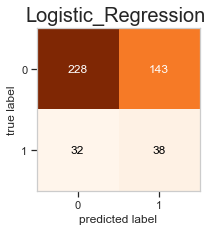

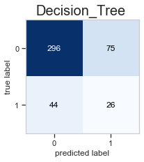

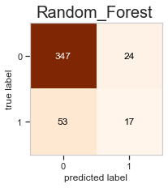

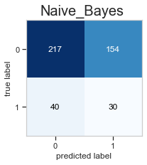

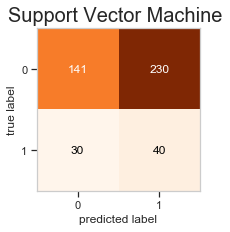

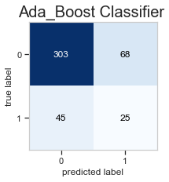

```python
binary1 = np.array(cf_logi)
binary2 = np.array(cf_dt)
binary3 = np.array(cf_rfc)
binary4 = np.array(cf_nb)
binary5 = np.array(cf_svc)
binary6 = np.array(cf_abc)

fig, ax = plot_confusion_matrix(conf_mat=binary1,figsize=(3, 3),cmap='Oranges')
plt.suptitle('Logistic_Regression' ,fontsize= 20)
fig, ax1 = plot_confusion_matrix(conf_mat=binary2,figsize=(3, 3))
plt.suptitle('Decision_Tree' ,fontsize= 20)
fig, ax = plot_confusion_matrix(conf_mat=binary3,figsize=(3, 3),cmap='Oranges')
plt.suptitle('Random_Forest' ,fontsize= 20)
fig, ax = plot_confusion_matrix(conf_mat=binary4,figsize=(3, 3))
plt.suptitle('Naive_Bayes' ,fontsize= 20)
fig, ax = plot_confusion_matrix(conf_mat=binary5,figsize=(3, 3),cmap='Oranges')
plt.suptitle('Support Vector Machine' ,fontsize= 20)
fig, ax = plot_confusion_matrix(conf_mat=binary6,figsize=(3, 3))
plt.suptitle('Ada_Boost Classifier' ,fontsize= 20)
plt.show()
```

# 9 Evaluate all models

### 9.1 Accuracy scores

```python
from sklearn.metrics import accuracy_score
```

```python
Acc1_logmodel1 = accuracy_score(emp_data_y_test, pred1)
Acc1_dt1 = accuracy_score(emp_data_y_test, pred1_dt)
Acc1_rfc1 = accuracy_score(emp_data_y_test, pred1_rfc)
Acc1_nb1 = accuracy_score(emp_data_y_test, pred1_nb)
Acc1_svc1 = accuracy_score(emp_data_y_test, pred1_svc)
Acc1_boost1 = accuracy_score(emp_data_y_test, pred1_abc)
AccuracyScores1 = [Acc1_logmodel1,Acc1_dt1,Acc1_rfc1,Acc1_nb1,Acc1_svc1,Acc1_boost1]
print (AccuracyScores1)
```

```
[0.6031746031746031, 0.7301587301587301, 0.8253968253968254, 0.5600907029478458, 0.41043083900226757, 0.7437641723356009]
```

### 9.2 Precision Scores

```python
from sklearn.metrics import precision_score
```

```python
Prec1_logmodel1 = precision_score(emp_data_y_test, pred1)
Prec1_dt1 = precision_score(emp_data_y_test, pred1_dt)
Prec1_rfc1 = precision_score(emp_data_y_test, pred1_rfc)
Prec1_nb1 = precision_score(emp_data_y_test, pred1_nb)
Prec1_svc1 = precision_score(emp_data_y_test, pred1_svc)
Prec1_boost1 = precision_score(emp_data_y_test, pred1_abc)
PrecisionScores1 = [Prec1_logmodel1,Prec1_dt1,Prec1_rfc1,Prec1_nb1,Prec1_svc1,Prec1_boost1]
print (PrecisionScores1)
```

```
[0.20994475138121546, 0.25742574257425743, 0.4146341463414634, 0.16304347826086957, 0.14814814814814814, 0.26881720430107525]
```

### 9.3 Recall / Sensitivity

```python
from sklearn.metrics import recall_score
```

```python
Rec1_logmodel1 = recall_score(emp_data_y_test, pred1)
Rec1_dt1 = recall_score(emp_data_y_test, pred1_dt)
Rec1_rfc1 = recall_score(emp_data_y_test, pred1_rfc)
Rec1_nb1 = recall_score(emp_data_y_test, pred1_nb)
Rec1_svc1 = recall_score(emp_data_y_test, pred1_svc)
Rec1_boost1 = recall_score(emp_data_y_test, pred1_abc)
Recall_Sensitivity1 = [Rec1_logmodel1,Rec1_dt1,Rec1_rfc1,Rec1_nb1,Rec1_svc1,Rec1_boost1]
print (Recall_Sensitivity1)
```

```
[0.5428571428571428, 0.37142857142857144, 0.24285714285714285, 0.42857142857142855, 0.5714285714285714, 0.35714285714285715]
```

### 9.3 Specificity (Recall of Negative class or class "0")

```python
spec1_logmodel1 = recall_score(emp_data_y_test, pred1,pos_label=0)
spec1_dt1 = recall_score(emp_data_y_test, pred1_dt,pos_label=0)
spec1_rfc1 = recall_score(emp_data_y_test, pred1_rfc,pos_label=0)
spec1_nb1 = recall_score(emp_data_y_test, pred1_nb,pos_label=0)
spec1_svc1 = recall_score(emp_data_y_test, pred1_svc,pos_label=0)
spec1_boost1 = recall_score(emp_data_y_test, pred1_abc,pos_label=0)
specificity1 = [spec1_logmodel1,spec1_dt1,spec1_rfc1,spec1_nb1,spec1_svc1,spec1_boost1]
print (specificity1)
```

```
[0.6145552560646901, 0.7978436657681941, 0.9353099730458221, 0.5849056603773585, 0.38005390835579517, 0.816711590296496]
```

### 9.4 Kappa Value

```python
from sklearn.metrics import cohen_kappa_score
```

```python
kappa1_logmodel1 = cohen_kappa_score(emp_data_y_test, pred1)
kappa1_dt1 = cohen_kappa_score(emp_data_y_test, pred1_dt)
kappa1_rfc1 = cohen_kappa_score(emp_data_y_test, pred1_rfc)
kappa1_nb1 = cohen_kappa_score(emp_data_y_test, pred1_nb)
kappa1_svc1 = cohen_kappa_score(emp_data_y_test, pred1_svc)
kappa1_boost1 = cohen_kappa_score(emp_data_y_test, pred1_abc)
Kappa_Value1= [kappa1_logmodel1,kappa1_dt1,kappa1_rfc1,kappa1_nb1,kappa1_svc1,kappa1_boost1]
print (Kappa_Value1)
```

```
[0.09579266792421881, 0.14349365931680558, 0.2141584318807711, 0.008115565654925994, -0.022471910112359605, 0.1534070638601499]
```

### 9.5 Compare Models

```python
Names = ["LogisticReg1","DecisionTree1","RandomForest1","NaiveByes1","SVM1","Boosting1"]
```

```python
df = pd.DataFrame(list(zip(Names, AccuracyScores1,PrecisionScores1,Recall_Sensitivity1,specificity1, Kappa_Value1)),
               columns =['Model_Name', 'Accuracy', 'Precision',"Recall/Sensitivity",'specificity', "Kappa_Value"])
df2 =df.sort_values(by=['Accuracy'], ascending=False)
cm = sns.light_palette("green", as_cmap=True)
Model_comparison_1 = df2.style.background_gradient(cmap=cm)
Model_comparison_1
```

|  | Model_Name | Accuracy | Precision | Recall/Sensitivity | specificity | Kappa_Value |
| --- | --- | --- | --- | --- | --- | --- |
| 2 | RandomForest1 | 0.825397 | 0.414634 | 0.242857 | 0.935310 | 0.214158 |
| 5 | Boosting1 | 0.743764 | 0.268817 | 0.357143 | 0.816712 | 0.153407 |
| 1 | DecisionTree1 | 0.730159 | 0.257426 | 0.371429 | 0.797844 | 0.143494 |
| 0 | LogisticReg1 | 0.603175 | 0.209945 | 0.542857 | 0.614555 | 0.095793 |
| 3 | NaiveByes1 | 0.560091 | 0.163043 | 0.428571 | 0.584906 | 0.008116 |
| 4 | SVM1 | 0.410431 | 0.148148 | 0.571429 | 0.380054 | -0.022472 |

## 10. Feature Selection (Level-2 )

```python
from sklearn.feature_selection import VarianceThreshold
from sklearn.feature_selection import SelectFromModel
from sklearn.ensemble import RandomForestClassifier
from sklearn.feature_selection import SelectKBest
from sklearn.feature_selection import chi2
from sklearn.tree import DecisionTreeClassifier
!pip install boruta
from boruta import BorutaPy
from sklearn.feature_selection import RFE
```

### 10.1 Select-K-Best

```python
test= SelectKBest(score_func=chi2,k=10)
```

fitted_cr = test.fit(emp_data_x, emp_data_y)

```python
fitted_scr = test.fit(emp_data_x, emp_data_y)
df3 = pd.DataFrame({"Feauture": emp_data_x.columns, "Select-K-Best Score": fitted_scr.scores_})
df3
```

|  | Feauture | Select-K-Best Score |
| --- | --- | --- |
| 0 | Age | 84.155277 |
| 1 | BusinessTravel | 0.000002 |
| 2 | DailyRate | 956.580494 |
| 3 | Department | 1.329297 |
| 4 | DistanceFromHome | 63.772142 |
| 5 | Education | 0.520642 |
| 6 | EducationField | 0.834912 |
| 7 | EmployeeNumber | 58.120326 |
| 8 | EnvironmentSatisfaction | 6.890594 |
| 9 | Gender | 0.510087 |
| 10 | HourlyRate | 0.431779 |
| 11 | JobInvolvement | 4.605616 |
| 12 | JobLevel | 24.939242 |
| 13 | JobRole | 9.004448 |
| 14 | JobSatisfaction | 7.011947 |
| 15 | MaritalStatus | 18.745657 |
| 16 | MonthlyRate | 1196.633553 |
| 17 | NumCompaniesWorked | 6.438654 |
| 18 | OverTime | 63.845067 |
| 19 | PercentSalaryHike | 0.235027 |
| 20 | PerformanceRating | 0.000506 |
| 21 | RelationshipSatisfaction | 1.332333 |
| 22 | StockOptionLevel | 25.268826 |
| 23 | TotalWorkingYears | 230.721618 |
| 24 | TrainingTimesLastYear | 3.085796 |
| 25 | WorkLifeBalance | 1.085543 |
| 26 | YearsAtCompany | 142.100054 |
| 27 | YearsInCurrentRole | 117.522596 |
| 28 | YearsSinceLastPromotion | 7.601723 |
| 29 | YearsWithCurrManager | 110.671534 |

### 10.2 Boruta

```python
emp_data_x1 = np.array(emp_data_x)
emp_data_y1 = np.array(emp_data_y)
rf = RandomForestClassifier()
boruta_feature_selector = BorutaPy(rf, random_state = 111, max_iter = 25, perc = 100, verbose = 2)
boruta_feature_selector.fit(emp_data_x1, emp_data_y1)
df4 = pd.DataFrame({"Column name": emp_data_x.columns, "Feature": boruta_feature_selector.support_})
df4
```

[output not shown]

[output cut: 49 more lines]

```
Confirmed: 	3
Tentative: 	1
Rejected: 	26
Iteration: 	24 / 25
Confirmed: 	3
Tentative: 	1
Rejected: 	26


BorutaPy finished running.

Iteration: 	25 / 25
Confirmed: 	3
Tentative: 	1
Rejected: 	26
```

|  | Column name | Feature |
| --- | --- | --- |
| 0 | Age | True |
| 1 | BusinessTravel | False |
| 2 | DailyRate | False |
| 3 | Department | False |
| 4 | DistanceFromHome | False |
| 5 | Education | False |
| 6 | EducationField | False |
| 7 | EmployeeNumber | False |
| 8 | EnvironmentSatisfaction | False |
| 9 | Gender | False |
| 10 | HourlyRate | False |
| 11 | JobInvolvement | False |
| 12 | JobLevel | False |
| 13 | JobRole | False |
| 14 | JobSatisfaction | False |
| 15 | MaritalStatus | False |
| 16 | MonthlyRate | False |
| 17 | NumCompaniesWorked | False |
| 18 | OverTime | True |
| 19 | PercentSalaryHike | False |
| 20 | PerformanceRating | False |
| 21 | RelationshipSatisfaction | False |
| 22 | StockOptionLevel | False |
| 23 | TotalWorkingYears | True |
| 24 | TrainingTimesLastYear | False |
| 25 | WorkLifeBalance | False |
| 26 | YearsAtCompany | False |
| 27 | YearsInCurrentRole | False |
| 28 | YearsSinceLastPromotion | False |
| 29 | YearsWithCurrManager | False |

### 10.3 Recursive Feature Selection (RFE)

```python
rfc = RandomForestClassifier()
rfe_rfc = RFE(rfc, 10) #...top 5 important feature
rfe_rfc.fit(emp_data_x, emp_data_y)
df5 = pd.DataFrame({"Column name": emp_data_x.columns, "Feature": rfe_rfc.support_})
df5
```

|  | Column name | Feature |
| --- | --- | --- |
| 0 | Age | True |
| 1 | BusinessTravel | False |
| 2 | DailyRate | True |
| 3 | Department | False |
| 4 | DistanceFromHome | True |
| 5 | Education | False |
| 6 | EducationField | False |
| 7 | EmployeeNumber | True |
| 8 | EnvironmentSatisfaction | False |
| 9 | Gender | False |
| 10 | HourlyRate | True |
| 11 | JobInvolvement | False |
| 12 | JobLevel | False |
| 13 | JobRole | True |
| 14 | JobSatisfaction | False |
| 15 | MaritalStatus | False |
| 16 | MonthlyRate | True |
| 17 | NumCompaniesWorked | False |
| 18 | OverTime | False |
| 19 | PercentSalaryHike | True |
| 20 | PerformanceRating | False |
| 21 | RelationshipSatisfaction | False |
| 22 | StockOptionLevel | False |
| 23 | TotalWorkingYears | True |
| 24 | TrainingTimesLastYear | False |
| 25 | WorkLifeBalance | False |
| 26 | YearsAtCompany | True |
| 27 | YearsInCurrentRole | False |
| 28 | YearsSinceLastPromotion | False |
| 29 | YearsWithCurrManager | False |

### 10.4 Feature Importance by Decision Tree

```python
dtree_fi = DecisionTreeClassifier()
dtree_fi.fit(emp_data_x, emp_data_y)
df6 = pd.DataFrame({"Feauture": emp_data_x.columns, "Importance": dtree_fi.feature_importances_})
df6
```

|  | Feauture | Importance |
| --- | --- | --- |
| 0 | Age | 0.069676 |
| 1 | BusinessTravel | 0.010340 |
| 2 | DailyRate | 0.064358 |
| 3 | Department | 0.006361 |
| 4 | DistanceFromHome | 0.023489 |
| 5 | Education | 0.006037 |
| 6 | EducationField | 0.004128 |
| 7 | EmployeeNumber | 0.069558 |
| 8 | EnvironmentSatisfaction | 0.052849 |
| 9 | Gender | 0.000000 |
| 10 | HourlyRate | 0.062701 |
| 11 | JobInvolvement | 0.025911 |
| 12 | JobLevel | 0.064001 |
| 13 | JobRole | 0.034751 |
| 14 | JobSatisfaction | 0.020635 |
| 15 | MaritalStatus | 0.044500 |
| 16 | MonthlyRate | 0.082399 |
| 17 | NumCompaniesWorked | 0.049594 |
| 18 | OverTime | 0.060574 |
| 19 | PercentSalaryHike | 0.035207 |
| 20 | PerformanceRating | 0.002515 |
| 21 | RelationshipSatisfaction | 0.007186 |
| 22 | StockOptionLevel | 0.009175 |
| 23 | TotalWorkingYears | 0.063911 |
| 24 | TrainingTimesLastYear | 0.026646 |
| 25 | WorkLifeBalance | 0.018670 |
| 26 | YearsAtCompany | 0.008489 |
| 27 | YearsInCurrentRole | 0.006348 |
| 28 | YearsSinceLastPromotion | 0.029428 |
| 29 | YearsWithCurrManager | 0.040565 |

### 10.5 Feature Importance by Random Forest

```python
rfc_fi = RandomForestClassifier()
rfc_fi.fit(emp_data_x, emp_data_y)
df7 = pd.DataFrame({"Feauture": emp_data_x.columns, "Importance": rfc_fi.feature_importances_})
df7
```

|  | Feauture | Importance |
| --- | --- | --- |
| 0 | Age | 0.066729 |
| 1 | BusinessTravel | 0.014332 |
| 2 | DailyRate | 0.053841 |
| 3 | Department | 0.013960 |
| 4 | DistanceFromHome | 0.046993 |
| 5 | Education | 0.021875 |
| 6 | EducationField | 0.023659 |
| 7 | EmployeeNumber | 0.048845 |
| 8 | EnvironmentSatisfaction | 0.030113 |
| 9 | Gender | 0.009224 |
| 10 | HourlyRate | 0.051025 |
| 11 | JobInvolvement | 0.026332 |
| 12 | JobLevel | 0.028085 |
| 13 | JobRole | 0.031189 |
| 14 | JobSatisfaction | 0.029327 |
| 15 | MaritalStatus | 0.022382 |
| 16 | MonthlyRate | 0.048994 |
| 17 | NumCompaniesWorked | 0.036623 |
| 18 | OverTime | 0.058950 |
| 19 | PercentSalaryHike | 0.035676 |
| 20 | PerformanceRating | 0.004973 |
| 21 | RelationshipSatisfaction | 0.025081 |
| 22 | StockOptionLevel | 0.028847 |
| 23 | TotalWorkingYears | 0.055393 |
| 24 | TrainingTimesLastYear | 0.026106 |
| 25 | WorkLifeBalance | 0.026766 |
| 26 | YearsAtCompany | 0.049457 |
| 27 | YearsInCurrentRole | 0.025307 |
| 28 | YearsSinceLastPromotion | 0.023771 |
| 29 | YearsWithCurrManager | 0.036143 |

### 10.6 Selection of Features

```python
Feature_selection = pd.DataFrame({"Feauture": emp_data_x.columns, "Select-K-Best Score": fitted_scr.scores_,
                                  "Importance(Decision Tree)": dtree1.feature_importances_, "Importance (RandomForest)": rfc1.feature_importances_,
                                 "Boruta-Support": boruta_feature_selector.support_,"RFE-Support": rfe_rfc.support_ })
Feature_selection=Feature_selection.sort_values(by=['Select-K-Best Score'], ascending=False)
cm = sns.light_palette("orange", as_cmap=True)
Feature_selection1 =  Feature_selection.style.background_gradient(cmap=cm)
Feature_selection1
```

|  | Feauture | Select-K-Best Score | Importance(Decision Tree) | Importance (RandomForest) | Boruta-Support | RFE-Support |
| --- | --- | --- | --- | --- | --- | --- |
| 16 | MonthlyRate | 1196.633553 | 0.046800 | 0.045529 | False | True |
| 2 | DailyRate | 956.580494 | 0.035958 | 0.045494 | False | True |
| 23 | TotalWorkingYears | 230.721618 | 0.015894 | 0.041959 | True | True |
| 26 | YearsAtCompany | 142.100054 | 0.008640 | 0.029443 | False | True |
| 27 | YearsInCurrentRole | 117.522596 | 0.016391 | 0.035109 | False | False |
| 29 | YearsWithCurrManager | 110.671534 | 0.010770 | 0.037196 | False | False |
| 0 | Age | 84.155277 | 0.032661 | 0.047250 | True | True |
| 18 | OverTime | 63.845067 | 0.023071 | 0.010543 | True | False |
| 4 | DistanceFromHome | 63.772142 | 0.046097 | 0.036258 | False | True |
| 7 | EmployeeNumber | 58.120326 | 0.035691 | 0.046191 | False | True |
| 22 | StockOptionLevel | 25.268826 | 0.181758 | 0.097097 | False | False |
| 12 | JobLevel | 24.939242 | 0.102515 | 0.056220 | False | False |
| 15 | MaritalStatus | 18.745657 | 0.030681 | 0.014973 | False | False |
| 13 | JobRole | 9.004448 | 0.027784 | 0.023759 | False | True |
| 28 | YearsSinceLastPromotion | 7.601723 | 0.019450 | 0.024236 | False | False |
| 14 | JobSatisfaction | 7.011947 | 0.023543 | 0.044459 | False | False |
| 8 | EnvironmentSatisfaction | 6.890594 | 0.049647 | 0.038503 | False | False |
| 17 | NumCompaniesWorked | 6.438654 | 0.026874 | 0.021813 | False | False |
| 11 | JobInvolvement | 4.605616 | 0.072129 | 0.059013 | False | False |
| 24 | TrainingTimesLastYear | 3.085796 | 0.026113 | 0.025615 | False | False |
| 21 | RelationshipSatisfaction | 1.332333 | 0.025608 | 0.026512 | False | False |
| 3 | Department | 1.329297 | 0.005220 | 0.008746 | False | False |
| 25 | WorkLifeBalance | 1.085543 | 0.022091 | 0.025705 | False | False |
| 6 | EducationField | 0.834912 | 0.011560 | 0.018079 | False | False |
| 5 | Education | 0.520642 | 0.019510 | 0.025325 | False | False |
| 9 | Gender | 0.510087 | 0.007631 | 0.010481 | False | False |
| 10 | HourlyRate | 0.431779 | 0.034955 | 0.037540 | False | True |
| 19 | PercentSalaryHike | 0.235027 | 0.017640 | 0.021945 | False | True |
| 20 | PerformanceRating | 0.000506 | 0.002578 | 0.003681 | False | False |
| 1 | BusinessTravel | 0.000002 | 0.020738 | 0.041326 | False | False |

From Feature Selection analyis we decided below faetures as important parameters

DailyRate, TotalWorkingYears ,YearsAtCompany, YearsInCurrentRole, YearsWithCurrManager, Age, OverTime, DistanceFromHome, EmployeeNumber , StockOptionLevel, JobLevel, MaritalStatus, JobRole , YearsSinceLastPromotion, JobSatisfaction, EnvironmentSatisfaction, NumCompaniesWorked, JobInvolvement, HourlyRate, PercentSalaryHike

# 11 Re-build the models

```python
import sklearn
from sklearn.linear_model import LogisticRegression
from sklearn.tree import DecisionTreeClassifier
from sklearn.ensemble import RandomForestClassifier
from sklearn.naive_bayes import MultinomialNB
from sklearn.svm import SVC
from sklearn.ensemble import AdaBoostClassifier
```

### Create instances for classifiers

```python
logmodel2= LogisticRegression()
dtree2 = DecisionTreeClassifier()
rfc2 = RandomForestClassifier()
naive_bay2= MultinomialNB()
svc_model2= SVC()
abc2 = AdaBoostClassifier (DecisionTreeClassifier(), n_estimators = 15)
```

### Train & Test data based on selected features

```python
new_empdata_x_train= emp_data_x_train.loc[:,['DailyRate', 'TotalWorkingYears' ,'YearsAtCompany', 'YearsInCurrentRole',
                                             'YearsWithCurrManager', 'Age', 'OverTime', 'DistanceFromHome',
                                             'StockOptionLevel', 'JobLevel', 'MaritalStatus', 'JobRole' , 'YearsSinceLastPromotion',
                                             'JobSatisfaction', 'EnvironmentSatisfaction', 'NumCompaniesWorked','JobInvolvement',
                                             'HourlyRate', 'PercentSalaryHike']]

new_empdata_x_test= emp_data_x_test.loc[:,['DailyRate', 'TotalWorkingYears' ,'YearsAtCompany', 'YearsInCurrentRole',
                                             'YearsWithCurrManager', 'Age', 'OverTime', 'DistanceFromHome',
                                             'StockOptionLevel', 'JobLevel', 'MaritalStatus', 'JobRole' , 'YearsSinceLastPromotion',
                                             'JobSatisfaction', 'EnvironmentSatisfaction', 'NumCompaniesWorked','JobInvolvement',
                                             'HourlyRate', 'PercentSalaryHike']]
```

```python
new_empdata_x_train.shape
```

```
(1724, 19)
```

```python
new_empdata_x_test.shape
```

```
(441, 19)
```

### Train the models

```python
logmodel2.fit(new_empdata_x_train, emp_data_y_train)
dtree2.fit(new_empdata_x_train, emp_data_y_train)
rfc2.fit(new_empdata_x_train, emp_data_y_train)
naive_bay2.fit(new_empdata_x_train, emp_data_y_train)
svc_model2.fit(new_empdata_x_train, emp_data_y_train)
abc2.fit(new_empdata_x_train, emp_data_y_train)
```

```
AdaBoostClassifier(algorithm='SAMME.R',
                   base_estimator=DecisionTreeClassifier(ccp_alpha=0.0,
                                                         class_weight=None,
                                                         criterion='gini',
                                                         max_depth=None,
                                                         max_features=None,
                                                         max_leaf_nodes=None,
                                                         min_impurity_decrease=0.0,
                                                         min_impurity_split=None,
                                                         min_samples_leaf=1,
                                                         min_samples_split=2,
                                                         min_weight_fraction_leaf=0.0,
                                                         presort='deprecated',
                                                         random_state=None,
                                                         splitter='best'),
                   learning_rate=1.0, n_estimators=15, random_state=None)
```

## Predict on Test data

```python
pred2 = logmodel2.predict(new_empdata_x_test)
pred2_dt = dtree2.predict(new_empdata_x_test)
pred2_rfc = rfc2.predict(new_empdata_x_test)
pred2_nb =naive_bay2.predict(new_empdata_x_test)
pred2_svc = svc_model2.predict(new_empdata_x_test)
pred2_abc = abc2.predict(new_empdata_x_test)
```

### Compare Confusion Matrices of all the above models

```python
from mlxtend.plotting import plot_confusion_matrix
import matplotlib.pyplot as plt
import numpy as np
```

```python
cm_logi = confusion_matrix(emp_data_y_test,pred2)
cm_dt= confusion_matrix(emp_data_y_test,pred2_dt)
cm_rfc = confusion_matrix(emp_data_y_test,pred2_rfc)
cm_nb= confusion_matrix(emp_data_y_test,pred2_nb)
cm_svc= confusion_matrix(emp_data_y_test,pred2_svc)
cm_abc = confusion_matrix(emp_data_y_test,pred2_abc)
```

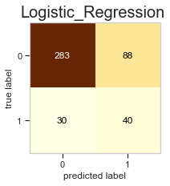

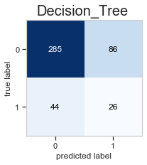

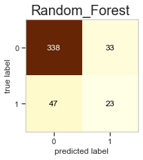

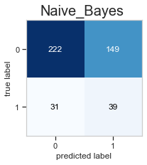

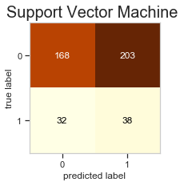

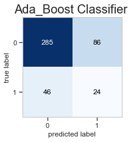

```python
binary7 = np.array(cm_logi)
binary8 = np.array(cm_dt)
binary9 = np.array(cm_rfc)
binary10 = np.array(cm_nb)
binary11 = np.array(cm_svc)
binary12 = np.array(cm_abc)

fig, ax = plot_confusion_matrix(conf_mat=binary7,figsize=(3, 3),cmap='YlOrBr')
plt.suptitle('Logistic_Regression' ,fontsize= 20)
fig, ax1 = plot_confusion_matrix(conf_mat=binary8,figsize=(3, 3))
plt.suptitle('Decision_Tree' ,fontsize= 20)
fig, ax = plot_confusion_matrix(conf_mat=binary9,figsize=(3, 3),cmap='YlOrBr')
plt.suptitle('Random_Forest' ,fontsize= 20)
fig, ax = plot_confusion_matrix(conf_mat=binary10,figsize=(3, 3))
plt.suptitle('Naive_Bayes' ,fontsize= 20)
fig, ax = plot_confusion_matrix(conf_mat=binary11,figsize=(3, 3),cmap='YlOrBr')
plt.suptitle('Support Vector Machine' ,fontsize= 20)
fig, ax = plot_confusion_matrix(conf_mat=binary12,figsize=(3, 3))
plt.suptitle('Ada_Boost Classifier' ,fontsize= 20)
plt.show()
```

### Generate Accuracy Scores for all new models

```python
from sklearn.metrics import accuracy_score

Acc2_logmodel2 = accuracy_score(emp_data_y_test, pred2)
Acc2_dt2 = accuracy_score(emp_data_y_test, pred2_dt)
Acc2_rfc2 = accuracy_score(emp_data_y_test, pred2_rfc)
Acc2_nb2 = accuracy_score(emp_data_y_test, pred2_nb)
Acc2_svc2 = accuracy_score(emp_data_y_test, pred2_svc)
Acc2_boost2 = accuracy_score(emp_data_y_test, pred2_abc)
AccuracyScores2 = [Acc2_logmodel2,Acc2_dt2,Acc2_rfc2,Acc2_nb2,Acc2_svc2,Acc2_boost2]
print (AccuracyScores2)
```

```
[0.7324263038548753, 0.7052154195011338, 0.81859410430839, 0.5918367346938775, 0.4671201814058957, 0.7006802721088435]
```

### Generate Precision Scores for all new models

```python
from sklearn.metrics import precision_score

Prec2_logmodel2 = precision_score(emp_data_y_test, pred2)
Prec2_dt2 = precision_score(emp_data_y_test, pred2_dt)
Prec2_rfc2 = precision_score(emp_data_y_test, pred2_rfc)
Prec2_nb2 = precision_score(emp_data_y_test, pred2_nb)
Prec2_svc2 = precision_score(emp_data_y_test, pred2_svc)
Prec2_boost2 = precision_score(emp_data_y_test, pred2_abc)
PrecisionScores2 = [Prec2_logmodel2,Prec2_dt2,Prec2_rfc2,Prec2_nb2,Prec2_svc2,Prec2_boost2]
print (PrecisionScores2)
```

```
[0.3125, 0.23214285714285715, 0.4107142857142857, 0.2074468085106383, 0.15767634854771784, 0.21818181818181817]
```

### Generate Recall/Sensitivity Scores for all new models

```python
from sklearn.metrics import recall_score

Rec2_logmodel2 = recall_score(emp_data_y_test, pred2)
Rec2_dt2 = recall_score(emp_data_y_test, pred2_dt)
Rec2_rfc2 = recall_score(emp_data_y_test, pred2_rfc)
Rec2_nb2 = recall_score(emp_data_y_test, pred2_nb)
Rec2_svc2 = recall_score(emp_data_y_test, pred2_svc)
Rec2_boost2 = recall_score(emp_data_y_test, pred2_abc)
Recall_Sensitivity2 = [Rec2_logmodel2,Rec2_dt2,Rec2_rfc2,Rec2_nb2,Rec2_svc2,Rec2_boost2]
print (Recall_Sensitivity2)
```

```
[0.5714285714285714, 0.37142857142857144, 0.32857142857142857, 0.5571428571428572, 0.5428571428571428, 0.34285714285714286]
```

### Generate Specificity Scores for all new models

```python
spec2_logmodel2 = recall_score(emp_data_y_test, pred2,pos_label=0)
spec2_dt2 = recall_score(emp_data_y_test, pred2_dt,pos_label=0)
spec2_rfc2 = recall_score(emp_data_y_test, pred2_rfc,pos_label=0)
spec2_nb2 = recall_score(emp_data_y_test, pred2_nb,pos_label=0)
spec2_svc2 = recall_score(emp_data_y_test, pred2_svc,pos_label=0)
spec2_boost2 = recall_score(emp_data_y_test, pred2_abc,pos_label=0)
specificity2 = [spec2_logmodel2,spec2_dt2,spec2_rfc2,spec2_nb2,spec2_svc2,spec2_boost2]
print (specificity2)
```

```
[0.7628032345013477, 0.7681940700808625, 0.9110512129380054, 0.5983827493261455, 0.4528301886792453, 0.7681940700808625]
```

### Generate Kappa Value Scores for all new models

```python
from sklearn.metrics import cohen_kappa_score

kappa2_logmodel2 = cohen_kappa_score(emp_data_y_test, pred2)
kappa2_dt2 = cohen_kappa_score(emp_data_y_test, pred2_dt)
kappa2_rfc2 = cohen_kappa_score(emp_data_y_test, pred2_rfc)
kappa2_nb2 = cohen_kappa_score(emp_data_y_test, pred2_nb)
kappa2_svc2 = cohen_kappa_score(emp_data_y_test, pred2_svc)
kappa2_boost2 = cohen_kappa_score(emp_data_y_test, pred2_abc)
Kappa_Value2= [kappa2_logmodel2,kappa2_dt2,kappa2_rfc2,kappa2_nb2,kappa2_svc2,kappa2_boost2]
print (Kappa_Value2)
```

```
[0.250151301190236, 0.11229135053110784, 0.2607802874743327, 0.0923643348807427, -0.002166113856359564, 0.0901531728665208]
```

```python
from IPython.core.display import HTML

def multi_table(table_list):
    ''' Acceps a list of IpyTable objects and returns a table which contains each IpyTable in a cell
    '''
    return HTML(
        '<table><tr style="background-color:white;">' +
        ''.join(['<td>' + table._repr_html_() + '</td>' for table in table_list]) +
        '</tr></table>'
    )
```

```python
multi_table([Model_comparison_1,Model_comparison_2])
```

|  | Model_Name | Accuracy | Precision | Recall/Sensitivity | specificity | Kappa_Value |
| --- | --- | --- | --- | --- | --- | --- |
| 2 | RandomForest1 | 0.825397 | 0.414634 | 0.242857 | 0.935310 | 0.214158 |
| 5 | Boosting1 | 0.743764 | 0.268817 | 0.357143 | 0.816712 | 0.153407 |
| 1 | DecisionTree1 | 0.730159 | 0.257426 | 0.371429 | 0.797844 | 0.143494 |
| 0 | LogisticReg1 | 0.603175 | 0.209945 | 0.542857 | 0.614555 | 0.095793 |
| 3 | NaiveByes1 | 0.560091 | 0.163043 | 0.428571 | 0.584906 | 0.008116 |
| 4 | SVM1 | 0.410431 | 0.148148 | 0.571429 | 0.380054 | -0.022472 |

|  | Model_Name | Accuracy | Precision | Recall/Sensitivity | specificity | Kappa_Value |
| --- | --- | --- | --- | --- | --- | --- |
| 2 | RandomForest2 | 0.818594 | 0.410714 | 0.328571 | 0.911051 | 0.260780 |
| 0 | LogisticReg2 | 0.732426 | 0.312500 | 0.571429 | 0.762803 | 0.250151 |
| 1 | DecisionTree2 | 0.705215 | 0.232143 | 0.371429 | 0.768194 | 0.112291 |
| 5 | Boosting2 | 0.700680 | 0.218182 | 0.342857 | 0.768194 | 0.090153 |
| 3 | NaiveByes2 | 0.591837 | 0.207447 | 0.557143 | 0.598383 | 0.092364 |
| 4 | SVM2 | 0.467120 | 0.157676 | 0.542857 | 0.452830 | -0.002166 |

### From above model comparison it oberved that Logistic Regression Model-2 is best suitable for our use case with below metrci scores

## Selected Model: Logistic Regression model-2

### Accuracy: 73.24 %

### Recall / Sensitivity: 57.14 % (ability to predict correctly all positives means employees with attrition )

### Specificity : 76.28 % (ability to predict correctly all negative means employees not leaving organization)

### Kappa value : 0.2501

```python
import pickle
```

```python
LogisticRegression_model = logmodel2.fit(new_Attr_data_x_train, Attr_data_y_train)
```

```python
#..Save the model with new name
with open("LogisticRegression_model_selected", "wb")as f:
    pickle.dump(LogisticRegression_model, f)
```

# 🙏🙏🙏🙏🙏🙏🙏🙏 Thank You 🙏🙏🙏🙏🙏🙏🙏🙏🙏🙏🙏